# Определение рыночной стоимости объектов недвижимости

### Предобработка данных

```python
# Определим количество пропущенных значений для каждого столбца
data.isna().sum()
```

```
total_images                0
last_price                  0
total_area                  0
first_day_exposition        0
rooms                       0
ceiling_height           9195
floors_total               86
living_area              1903
floor                       0
is_apartment            20924
studio                      0
open_plan                   0
kitchen_area             2278
balcony                 11519
locality_name              49
airports_nearest         5542
cityCenters_nearest      5519
parks_around3000         5518
parks_nearest           15620
ponds_around3000         5518
ponds_nearest           14589
days_exposition          3181
dtype: int64
```

**Выясним возможные причины появления пропусков в датасете и возможные пути их заполнения**

`ceiling_height` (высота потолков). Пропуски в данном столбце возможны по причине продовца, который не указал данный параметр. Пропуски можно заполнить медианным значением в зависимости от удаленности расположения недвижимости от центра. Можно создать категории. Например, удаленность от центра в диапазоне 0-5 км - категория "А", 6-10 км - категория "В"; 11-20 км - категория "С"; 21-35 км - категория "D"; 36-66 км - категория "E".

`floors_total` (этажей в доме). Пропуски в данном столбце возможны по причине продавца, который не указал данный параметр. Данные строки с пропусками можно заполнить средним значением.

`living_area` (жилая площадь в квадратных метрах). Пропуски в данном столбце возможны по причине продавца, который не указал данный параметр. Данный параметр для анализа важен. Заполнить пропуски можно введением коэффициентов площади помещений квартиры в зависимости от количества комнат. Можно сгрупировать по количеству комнат в квартире и в зависимости от этого выделить доли. Для однокомнатной квартиры доля жилой площади будет определятся как 0.45 умноженное на общую площадь квартиры. Для двухкомнатной - 0,5хобщ.площ.кв. Для трехкомнатной - 0,55хобщ.площ.кв. Для четырехкомнатной - 0,6хобщ.площ.кв. Для пятикомнатной и n-комнатной - 0,7хобщ.площ.кв. Для студии (количество комнат равно 0) - 0,35хобщ.площ.кв.

`is_apartment` (апартаменты (булев тип)). Пропуски в данном столбце можно заменить на False. Можно предположить, что если в объявлении недвижимости не указано ничего об апартаментах, то такая недвижимость ей и не является.

`kitchen_area` (площадь кухни в квадратных метрах). Пропуски в данном столбце возможны по причине продавца, который не указал данный параметр. Данный параметр для анализа важен. Заполнить пропуски можно введением коэффициентов площади помещений квартиры в зависимости от количества комнат. Можно сгрупировать по количеству комнат в квартире и в зависимости от этого выделить доли. Для однокомнатной квартиры доля кухни будет определятся как 0.3 умноженное на общую площадь квартиры. Для двухкомнатной - 0,25хобщ.площ.кв. Для трехкомнатной - 0,18хобщ.площ.кв. Для четырехкомнатной - 0,15хобщ.площ.кв. Для пятикомнатной и n-комнатной - 0,13хобщ.площ.кв. Для студии (количество комнат равно 0) - 0,31хобщ.площ.кв.

`balcony` (число балконов). Пропуски в данном столбце можно заменить на 0. Можно предположить, что если в объявлении недвижимости не указано ничего о балконах, то такая недвижимость не имеет балконов.

`airports_nearest` (расстояние до ближайшего аэропорта в метрах). Данные пропуски, предположительно, заменить затрудняется. Пока оставим этот столбец как и есть.

`cityCenters_nearest` (расстояние до центра города в метрах). Данные пропуски, предположительно, заменить затрудняется. Пока оставим этот столбец как и есть.

`parks_around3000` (число парков в радиусе 3 км). Пропуски в данном столбце можно заменить на 0. Можно предположить, что если в объявлении недвижимости не указано ничего о наличии поблизости парков, то такая недвижимость не имеет в радиусе 3 км парка.

`parks_nearest` (расстояние до ближайшего парка в метрах). Данные пропуски, предположительно, заменить затрудняется. Пока оставим этот столбец как и есть.

`ponds_around3000` (число водоёмов в радиусе 3 км). Пропуски в данном столбце можно заменить на 0. Можно предположить, что если в объявлении недвижимости не указано ничего о наличии поблизости водоемов, то такая недвижимость не имеет в радиусе 3 км водоема.

`ponds_nearest` (расстояние до ближайшего водоёма в метрах). Данные пропуски, предположительно, заменить затрудняется. Пока оставим этот столбец как и есть.

`days_exposition` (сколько дней было размещено объявление (от публикации до снятия)). Данные пропуски, предположительно, заменить затрудняется. Пока оставим этот столбец как и есть.

*Создадим столбец `remoteness_category` с категориями удаленности расположения объекта недвижимости от центра:*

- 0-5000 метров - 'A'
- 5001-10000 метров - 'B'
- 10001-20000 метров - 'C'
- 20001-35000 метров - 'D'
- 35001-66000 метров - 'E'

```python
def categorize_remoteness(remoteness):
    try:
        if 0 <= remoteness <= 5000:
            return 'A'
        elif 5001 <= remoteness <= 10000:
            return 'B'
        elif 10001 <= remoteness <= 20000:
            return 'C'
        elif 20001 <= remoteness <= 35000:
            return 'D'
        elif 35001 <= remoteness <= 66000:
            return 'E'
    except:
        pass
```

```python
data['remoteness_category'] = data['cityCenters_nearest'].apply(categorize_remoteness)
```

*Заполним пропуски в столбце `ceiling_height` медианными значениями по каждому типу категории удаленности расположения объекта недвижимости от центра `remoteness_category`*

```python
for i in data['remoteness_category'].unique():
    data.loc[(data['remoteness_category'] == i) & (data['ceiling_height'].isna()), 'ceiling_height'] = \
    data.loc[(data['remoteness_category'] == i), 'ceiling_height'].median()
    #data.isna().sum()
```

*Строки с пропусками в столбце `floors_total` заполним средним значением.*

```python
mean_floors = data['floors_total'].mean().round(0)
data['floors_total'] = data['floors_total'].fillna(mean_floors)
#data.isna().sum()
```

*Заполним пропуски в столбце `living_area`, применив коэффициенты доли жилой площади к общей площади объекта недвижимости* Коэффициенты были подобраны исходя из стандартного отношения жилой площади к общей площади квартиры в зависимости от количества комнат в квартире.

```python
data.loc[(data['living_area'].isna()) & (data['rooms'] == 0), 'living_area'] = data['total_area']*0.35
data.loc[(data['living_area'].isna()) & (data['rooms'] == 1), 'living_area'] = data['total_area']*0.45
data.loc[(data['living_area'].isna()) & (data['rooms'] == 2), 'living_area'] = data['total_area']*0.5
data.loc[(data['living_area'].isna()) & (data['rooms'] == 3), 'living_area'] = data['total_area']*0.55
data.loc[(data['living_area'].isna()) & (data['rooms'] == 4), 'living_area'] = data['total_area']*0.6
data.loc[(data['living_area'].isna()) & (data['rooms'] >= 5), 'living_area'] = data['total_area']*0.7
#data.isna().sum()
```

*Заполним пропуски в столбце `is_apartment` значением False*

```python
data['is_apartment'] = data['is_apartment'].fillna(False)
#data.isna().sum()
```

*Заполним пропуски в столбце `kitchen_area`, применив коэффициенты доли площади кухни к общей площади объекта недвижимости* Коэффициенты были подобраны исходя из стандартного отношения площади кухни к общей площади квартиры в зависимости от количества комнат в квартире.

```python
data.loc[(data['kitchen_area'].isna()) & (data['rooms'] == 0), 'kitchen_area'] = data['total_area']*0.31
data.loc[(data['kitchen_area'].isna()) & (data['rooms'] == 1), 'kitchen_area'] = data['total_area']*0.3
data.loc[(data['kitchen_area'].isna()) & (data['rooms'] == 2), 'kitchen_area'] = data['total_area']*0.25
data.loc[(data['kitchen_area'].isna()) & (data['rooms'] == 3), 'kitchen_area'] = data['total_area']*0.18
data.loc[(data['kitchen_area'].isna()) & (data['rooms'] == 4), 'kitchen_area'] = data['total_area']*0.15
data.loc[(data['kitchen_area'].isna()) & (data['rooms'] >= 5), 'kitchen_area'] = data['total_area']*0.13
#data.isna().sum()
```

*Заполним пропуски в столбце `balcony` значением 0*

```python
data['balcony'] = data['balcony'].fillna(0)
#data.isna().sum()
```

*Строки с пропусками в столбце `locality_name` заполним строкой 'unknown'.*

```python
data['locality_name'] = data['locality_name'].fillna('unknown')
#data.isna().sum()
```

*Заполним пропуски в столбце `parks_around3000` значением 0*

```python
data['parks_around3000'] = data['parks_around3000'].fillna(0)
#data.isna().sum()
```

*Заполним пропуски в столбце `ponds_around3000` значением 0*

```python
data['ponds_around3000'] = data['ponds_around3000'].fillna(0)
#data.isna().sum()
```

**Проверим еще раз количество пропусков по столбцам и убедимся, что заполнили возможные пропущенные значения**

```python
data.isna().sum()
```

```
total_images                0
last_price                  0
total_area                  0
first_day_exposition        0
rooms                       0
ceiling_height           2575
floors_total                0
living_area                 0
floor                       0
is_apartment                0
studio                      0
open_plan                   0
kitchen_area                0
balcony                     0
locality_name               0
airports_nearest         5542
cityCenters_nearest      5519
parks_around3000            0
parks_nearest           15620
ponds_around3000            0
ponds_nearest           14589
days_exposition          3181
remoteness_category      5519
dtype: int64
```

```python
#Далее рассмотрим типы данных в каждом столбце. Вызовем еще раз метод info()
data.info()
```

```
<class 'pandas.core.frame.DataFrame'>
RangeIndex: 23699 entries, 0 to 23698
Data columns (total 23 columns):
 #   Column                Non-Null Count  Dtype
---  ------                --------------  -----
 0   total_images          23699 non-null  int64
 1   last_price            23699 non-null  float64
 2   total_area            23699 non-null  float64
 3   first_day_exposition  23699 non-null  object
 4   rooms                 23699 non-null  int64
 5   ceiling_height        21124 non-null  float64
 6   floors_total          23699 non-null  float64
 7   living_area           23699 non-null  float64
 8   floor                 23699 non-null  int64
 9   is_apartment          23699 non-null  bool
 10  studio                23699 non-null  bool
 11  open_plan             23699 non-null  bool
 12  kitchen_area          23699 non-null  float64
 13  balcony               23699 non-null  float64
 14  locality_name         23699 non-null  object
 15  airports_nearest      18157 non-null  float64
 16  cityCenters_nearest   18180 non-null  float64
 17  parks_around3000      23699 non-null  float64
 18  parks_nearest         8079 non-null   float64
 19  ponds_around3000      23699 non-null  float64
 20  ponds_nearest         9110 non-null   float64
 21  days_exposition       20518 non-null  float64
 22  remoteness_category   18180 non-null  object
dtypes: bool(3), float64(14), int64(3), object(3)
memory usage: 3.7+ MB
```

**Необходимо заменить следующие типы данных в столбцах:**

- `first_day_exposition` с типа "object" на тип "datetime64", так как значения в данном столбце являются датами;
- `floors_total` с типа "float64" на тип "int64", так как количество этажей это целочисленное значение;
- `balcony` с типа "float64" на тип "int64", так как количество балконов это целочисленное значение;
- `parks_around3000` с типа "float64" на тип "int64", так как количество парков это целочисленное значение;
- `ponds_around3000` с типа "float64" на тип "int64", так как количество водоемов это целочисленное значение.

```python
data['first_day_exposition'] = pd.to_datetime(data['first_day_exposition'], format='%Y-%m-%dT%H:%M:%S')
```

```python
data['floors_total'] = data['floors_total'].astype(int)
data['balcony'] = data['balcony'].astype(int)
data['parks_around3000'] = data['parks_around3000'].astype(int)
data['ponds_around3000'] = data['ponds_around3000'].astype(int)
data.info()
```

```
<class 'pandas.core.frame.DataFrame'>
RangeIndex: 23699 entries, 0 to 23698
Data columns (total 23 columns):
 #   Column                Non-Null Count  Dtype
---  ------                --------------  -----
 0   total_images          23699 non-null  int64
 1   last_price            23699 non-null  float64
 2   total_area            23699 non-null  float64
 3   first_day_exposition  23699 non-null  datetime64[ns]
 4   rooms                 23699 non-null  int64
 5   ceiling_height        21124 non-null  float64
 6   floors_total          23699 non-null  int64
 7   living_area           23699 non-null  float64
 8   floor                 23699 non-null  int64
 9   is_apartment          23699 non-null  bool
 10  studio                23699 non-null  bool
 11  open_plan             23699 non-null  bool
 12  kitchen_area          23699 non-null  float64
 13  balcony               23699 non-null  int64
 14  locality_name         23699 non-null  object
 15  airports_nearest      18157 non-null  float64
 16  cityCenters_nearest   18180 non-null  float64
 17  parks_around3000      23699 non-null  int64
 18  parks_nearest         8079 non-null   float64
 19  ponds_around3000      23699 non-null  int64
 20  ponds_nearest         9110 non-null   float64
 21  days_exposition       20518 non-null  float64
 22  remoteness_category   18180 non-null  object
dtypes: bool(3), datetime64[ns](1), float64(10), int64(7), object(2)
memory usage: 3.7+ MB
```

*Далее изучим столбец с названиями населенных пунктов расположения объектов недвижимости `locality_name`. В данном столбце наблюдаются неявные дубликаты, от них необходимо избавиться. Для этого применим метод replace()*

```python
#Выведем уникальные названия населенных пунктов и изучим их на неявные дубликаты
data['locality_name'].nunique()
```

```
365
```

```python
data['locality_name'] = data['locality_name'].str.replace('ё', 'е').replace('городской поселок', 'поселок городского типа', regex=True)
```

```python
data['locality_name'].nunique()
```

```
324
```

По количеству получившихся уникальных названий населенных пунктов, видно, что существовали неявные дупликаты и успешно получилось от них избавиться.

**Обработка аномальных значений**

```python
data['balcony'].unique()
```

```
array([0, 2, 1, 5, 4, 3])
```

```python
data['floor'].unique()
```

```
array([ 8,  1,  4,  9, 13,  5,  6, 22, 26,  7,  3,  2, 11, 15, 18, 10, 19,
       16, 20, 27, 25, 17, 14, 12, 21, 28, 24, 23, 30, 29, 32, 33, 31])
```

```python
data['floors_total'].unique()
```

```
array([16, 11,  5, 14, 12, 26, 24, 27,  9,  6, 17, 25,  3, 23, 19, 18,  4,
       22,  8,  2, 10,  7, 13, 15, 20, 28, 36, 21, 35, 34, 60,  1, 29, 33,
       52, 37])
```

```python
# Удалим строку с аномально-низким значением стоимости объекта недвижимости (12190)
data = data[data['last_price'] != 12190.0]
```

```python
data['rooms'].unique()
```

```
array([ 3,  1,  2,  4,  5,  6,  0,  7, 11,  8, 14, 10, 15,  9, 19, 16, 12])
```

```python
# Убедимся, что квартиры с количеством комнат 0 шт. это не аномалия, а лишь студия, либо квартира со свободной планировкой:
print('Квартира имеет 0 комнат и в тоже время не имеет свобоную планировку и не является студией:', data.query('rooms==0 and ~studio and ~open_plan')['rooms'].count())
```

```
Квартира имеет 0 комнат и в тоже время не имеет свобоную планировку и не является студией: 0
```

```python
# Посмотрим количество квартир с количеством комнат более 10 шт. Необходимо убедится в том, является ли это выбросом, либо это действительное вполне реально количество комнат в одной квартире
print('Количество квартир комнатами более 10 шт.:', data.query('rooms > 10')['rooms'].count())
```

```
Количество квартир комнатами более 10 шт.: 8
```

```python
#Больше похоже на выбросы, поэтому, удалим строки с количесвтом комнат более 10 шт.
data = data[data['rooms'] <= 10]
```

```python
data['ceiling_height'].unique()
```

```
array([  2.7 ,   2.6 ,   2.8 ,   3.03,    nan,   2.5 ,   2.67,   2.55,
         2.56,   3.05,   2.75,   3.1 ,   2.9 ,   3.  ,   2.65,   3.2 ,
         2.61,   3.25,   3.45,   2.77,   2.85,   2.64,   2.57,   4.15,
         3.5 ,   3.3 ,   2.71,   4.  ,   2.47,   2.73,   2.84,   2.34,
         3.4 ,   3.06,   2.72,   2.54,   2.51,   2.78,   2.76,  25.  ,
         2.58,   3.7 ,   2.52,   5.2 ,   2.87,   2.66,   2.59,   2.  ,
         2.45,   3.6 ,   2.92,   3.11,   3.13,   3.8 ,   3.15,   3.55,
         3.62,   3.12,   2.53,   2.74,   2.96,   2.46,   5.3 ,   5.  ,
         2.79,   2.95,   4.06,   2.94,   3.82,   3.54,   3.53,   2.83,
         4.7 ,   2.4 ,   3.38,   3.01,   5.6 ,   3.65,   3.9 ,   3.18,
         3.35,   2.3 ,   3.57,   2.48,   2.62,   2.82,   3.98,   2.63,
         3.83,   3.52,   3.95,   3.75,   2.88,   3.67,   3.87,   3.66,
         3.85,   3.86,   4.19,   3.24,   4.8 ,   4.5 ,   4.2 ,   3.36,
        32.  ,   3.08,   3.68,   3.07,   3.37,   3.09,   8.  ,   3.16,
         3.26,   3.34,   2.81,   3.44,   2.97,   3.14,   4.37,   2.68,
         3.22,   3.27,  27.  ,   4.1 ,   2.93,   3.46,  24.  ,   3.47,
         3.33,   3.63,   3.32,  26.  ,   1.2 ,   8.3 ,   2.98,   2.86,
         3.17,   4.4 ,   3.28,   3.04,   4.45,   5.5 ,   3.84,   3.23,
         3.02,   3.21,   3.78,   4.3 ,   3.39,   2.69,   3.31,   4.65,
         3.56,   2.2 ,   3.51,   3.93,   3.42,   2.99,   3.49,  14.  ,
         4.14,   2.91,   3.88,   1.75,   4.25,   3.29,  20.  ,   2.25,
         3.76,   3.69,   6.  ,  22.6 ,   2.89,   3.58,   5.8 ,  27.5 ,
         2.49,   4.9 ,   3.48,  10.3 ,   1.  , 100.  ,   3.59])
```

```python
# Обработаем аномалии в столбце с высотами потолков. Для этого значения высоты потолков более 21 метров поделим на 10:
data.update(data[data['ceiling_height'] >= 22]['ceiling_height']/10)
```

```python
# Посмотрим, сколько строк по итогу осталось после обработки дубликатов и аномальных значений:
data.shape
```

```
(23690, 23)
```

### Добавление в таблицу новых столбцов

**Необходимо для анализа добавить следующие столбцы с параметрами:**

- `price_meter`- цена одного квадратного метра;
- `day_publication` - день недели публикации объявления (0 — понедельник, 1 — вторник и так далее);
- `month_publication` - месяц публикации объявления;
- `year_publication` - год публикации объявления;
- `floor_type` - тип этажа квартиры (значения — «первый», «последний», «другой»)
- `cityCenters_nearest_km` - расстояние до центра города в километрах

```python
data['price_meter'] = data['last_price']/data['total_area']
```

```python
data['day_publication'] = data['first_day_exposition'].dt.weekday
```

```python
data['month_publication'] = data['first_day_exposition'].dt.month
```

```python
data['year_publication'] = data['first_day_exposition'].dt.year
```

```python
def categorize_floor(row):
    try:
        if row['floor'] == 1:
            return 'первый'
        elif row['floor'] == row['floors_total']:
            return 'последний'
        else:
            return 'другой'
    except:
        pass
data['floor_type'] = data.apply(categorize_floor, axis=1)
```

```python
data['cityCenters_nearest_km'] = data['cityCenters_nearest']/1000
data['cityCenters_nearest_km'] = data['cityCenters_nearest_km'].fillna(value=0).astype(int)
```

```python
#Выведем последние пятнадцать строк датасета, чтобы убедиться в достоверности добавленных столбцов
data.tail(15)
```

|  | total_images | last_price | total_area | first_day_exposition | rooms | ceiling_height | floors_total | living_area | floor | is_apartment | ... | ponds_around3000 | ponds_nearest | days_exposition | remoteness_category | price_meter | day_publication | month_publication | year_publication | floor_type | cityCenters_nearest_km |
| --- | --- | --- | --- | --- | --- | --- | --- | --- | --- | --- | --- | --- | --- | --- | --- | --- | --- | --- | --- | --- | --- |
| 23684 | 20 | 21400000.0 | 145.00 | 2018-11-02 | 4 | 3.00 | 26 | 71.400 | 17 | False | ... | 0 | NaN | NaN | C | 147586.206897 | 4 | 11 | 2018 | другой | 11 |
| 23685 | 15 | 2490000.0 | 31.00 | 2019-01-24 | 1 | 2.50 | 5 | 17.300 | 5 | False | ... | 0 | NaN | NaN | E | 80322.580645 | 3 | 1 | 2019 | последний | 51 |
| 23686 | 8 | 3300000.0 | 31.00 | 2017-04-29 | 1 | 2.55 | 9 | 18.000 | 6 | False | ... | 1 | 317.0 | 193.0 | C | 106451.612903 | 5 | 4 | 2017 | другой | 11 |
| 23687 | 6 | 3200000.0 | 39.00 | 2017-12-16 | 1 | 2.60 | 9 | 20.000 | 6 | False | ... | 0 | NaN | 38.0 | C | 82051.282051 | 5 | 12 | 2017 | другой | 16 |
| 23688 | 19 | 9200000.0 | 101.00 | 2019-04-01 | 3 | 3.05 | 15 | 63.000 | 12 | False | ... | 0 | NaN | 23.0 | C | 91089.108911 | 0 | 4 | 2019 | другой | 14 |
| 23689 | 13 | 3550000.0 | 35.30 | 2018-02-28 | 1 | 2.86 | 15 | 16.300 | 4 | False | ... | 2 | 652.0 | 29.0 | C | 100566.572238 | 2 | 2 | 2018 | другой | 16 |
| 23690 | 3 | 5500000.0 | 52.00 | 2018-07-19 | 2 | 2.80 | 5 | 31.000 | 2 | False | ... | 0 | NaN | 15.0 | B | 105769.230769 | 3 | 7 | 2018 | другой | 6 |
| 23691 | 11 | 9470000.0 | 72.90 | 2016-10-13 | 2 | 2.75 | 25 | 40.300 | 7 | False | ... | 1 | 806.0 | 519.0 | A | 129903.978052 | 3 | 10 | 2016 | другой | 4 |
| 23692 | 2 | 1350000.0 | 30.00 | 2017-07-07 | 1 | NaN | 5 | 17.500 | 4 | False | ... | 0 | NaN | 413.0 | None | 45000.000000 | 4 | 7 | 2017 | другой | 0 |
| 23693 | 9 | 4600000.0 | 62.40 | 2016-08-05 | 3 | 2.60 | 9 | 40.000 | 8 | False | ... | 1 | 675.0 | 239.0 | D | 73717.948718 | 4 | 8 | 2016 | другой | 34 |
| 23694 | 9 | 9700000.0 | 133.81 | 2017-03-21 | 3 | 3.70 | 5 | 73.300 | 3 | False | ... | 3 | 381.0 | NaN | A | 72490.845228 | 1 | 3 | 2017 | другой | 4 |
| 23695 | 14 | 3100000.0 | 59.00 | 2018-01-15 | 3 | NaN | 5 | 38.000 | 4 | False | ... | 0 | NaN | 45.0 | None | 52542.372881 | 0 | 1 | 2018 | другой | 0 |
| 23696 | 18 | 2500000.0 | 56.70 | 2018-02-11 | 2 | NaN | 3 | 29.700 | 1 | False | ... | 0 | NaN | NaN | None | 44091.710758 | 6 | 2 | 2018 | первый | 0 |
| 23697 | 13 | 11475000.0 | 76.75 | 2017-03-28 | 2 | 3.00 | 17 | 38.375 | 12 | False | ... | 3 | 196.0 | 602.0 | C | 149511.400651 | 1 | 3 | 2017 | другой | 10 |
| 23698 | 4 | 1350000.0 | 32.30 | 2017-07-21 | 1 | 2.50 | 5 | 12.300 | 1 | False | ... | 0 | NaN | NaN | None | 41795.665635 | 4 | 7 | 2017 | первый | 0 |

15 rows × 29 columns

### Проведение исследовательского анализа данных

**Изучим параметры**

```python
data.describe()
```

|  | total_images | last_price | total_area | rooms | ceiling_height | floors_total | living_area | floor | kitchen_area | balcony | ... | parks_around3000 | parks_nearest | ponds_around3000 | ponds_nearest | days_exposition | price_meter | day_publication | month_publication | year_publication | cityCenters_nearest_km |
| --- | --- | --- | --- | --- | --- | --- | --- | --- | --- | --- | --- | --- | --- | --- | --- | --- | --- | --- | --- | --- | --- |
| count | 23690.000000 | 2.369000e+04 | 23690.000000 | 23690.000000 | 21115.000000 | 23690.000000 | 23690.000000 | 23690.000000 | 23690.000000 | 23690.000000 | ... | 23690.000000 | 8074.000000 | 23690.000000 | 9105.000000 | 20510.000000 | 2.369000e+04 | 23690.000000 | 23690.000000 | 23690.000000 | 23690.000000 |
| mean | 9.859308 | 6.516600e+06 | 60.235242 | 2.066610 | 2.715851 | 10.675433 | 34.307962 | 5.891473 | 10.776497 | 0.591262 | ... | 0.468932 | 490.697919 | 0.590713 | 518.102252 | 180.816187 | 9.940795e+04 | 2.569143 | 6.400422 | 2017.367159 | 10.507936 |
| std | 5.682742 | 1.053998e+07 | 34.889058 | 1.055049 | 0.304600 | 6.584448 | 22.322358 | 4.882753 | 5.921329 | 0.959415 | ... | 0.748438 | 342.384852 | 0.883896 | 277.715394 | 219.556279 | 5.025285e+04 | 1.789025 | 3.491398 | 1.039684 | 9.508228 |
| min | 0.000000 | 4.300000e+05 | 12.000000 | 0.000000 | 1.000000 | 1.000000 | 2.000000 | 1.000000 | 1.300000 | 0.000000 | ... | 0.000000 | 1.000000 | 0.000000 | 13.000000 | 1.000000 | 7.962963e+03 | 0.000000 | 1.000000 | 2014.000000 | 0.000000 |
| 25% | 6.000000 | 3.400000e+06 | 40.000000 | 1.000000 | 2.590000 | 5.000000 | 18.600000 | 2.000000 | 7.200000 | 0.000000 | ... | 0.000000 | 288.000000 | 0.000000 | 294.000000 | 45.000000 | 7.658499e+04 | 1.000000 | 3.000000 | 2017.000000 | 2.000000 |
| 50% | 9.000000 | 4.650000e+06 | 52.000000 | 2.000000 | 2.600000 | 9.000000 | 30.000000 | 4.000000 | 9.600000 | 0.000000 | ... | 0.000000 | 454.000000 | 0.000000 | 502.000000 | 95.000000 | 9.500000e+04 | 3.000000 | 6.000000 | 2017.000000 | 11.000000 |
| 75% | 14.000000 | 6.790000e+06 | 69.787500 | 3.000000 | 2.800000 | 16.000000 | 42.000000 | 8.000000 | 12.000000 | 1.000000 | ... | 1.000000 | 612.000000 | 1.000000 | 730.000000 | 232.000000 | 1.142519e+05 | 4.000000 | 10.000000 | 2018.000000 | 15.000000 |
| max | 50.000000 | 7.630000e+08 | 631.200000 | 10.000000 | 20.000000 | 60.000000 | 441.700000 | 33.000000 | 148.230000 | 5.000000 | ... | 3.000000 | 3190.000000 | 3.000000 | 1344.000000 | 1580.000000 | 1.907500e+06 | 6.000000 | 12.000000 | 2019.000000 | 65.000000 |

8 rows × 22 columns

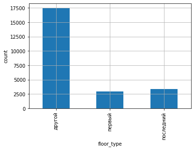

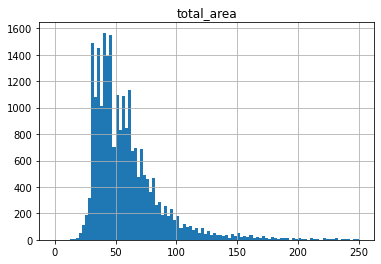

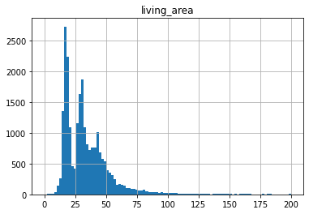

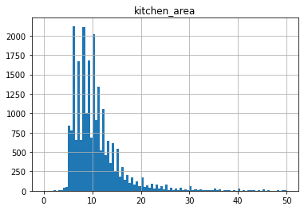

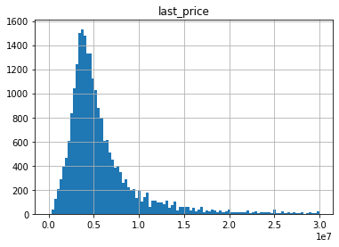

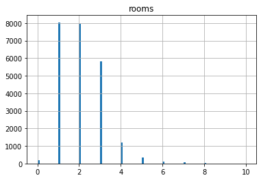

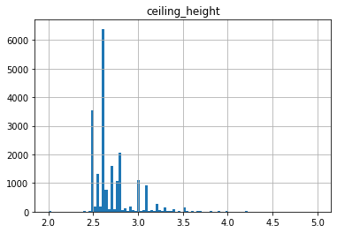

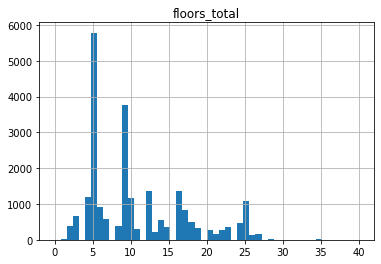

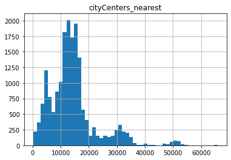

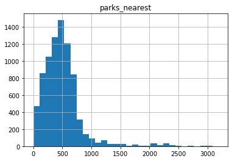

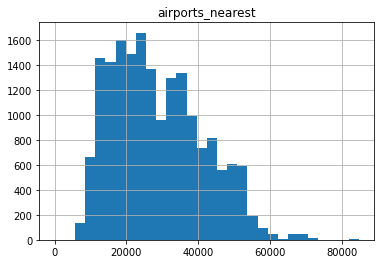

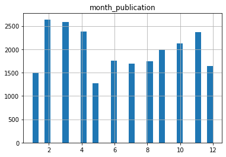

[1 more figures not shown]

```python
data.groupby(by='floor_type')['floor_type'].count().plot(kind='bar', ylabel = 'count', grid=True);
data.hist('total_area', bins=100, range=(0,250));
data.hist('living_area', bins=100, range=(0,200));
data.hist('kitchen_area', bins=100, range=(0,50));
data.hist('last_price', bins=100, range=(0,3e+07));
data.hist('rooms', bins=100);
data.hist('ceiling_height', bins=100, range=(2,5));
data.hist('floors_total', bins=50, range=(0,40));
data.hist('cityCenters_nearest', bins=50);
data.hist('parks_nearest', bins=30);
data.hist('airports_nearest', bins=30);
data.hist('month_publication', bins=30);
data.hist('day_publication', bins=30);
```

**Выводы по анализу полученных гистограмм для следующих параметров:**

На гистаграммах можно заметить "хвосты", так называемы выбросы у следующих столбцов:

- `total_area`
- `living_area`
- `kitchen_area`
- `last_price`

Отбросим эти выбросы.

```python
data = data[(data['total_area'] <= 110) & (data['living_area'] <= 65) & (data['kitchen_area'] <= 23)& (data['last_price'] <= 1e+07)]
```

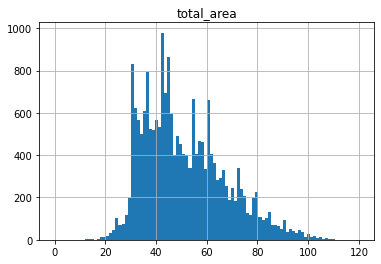

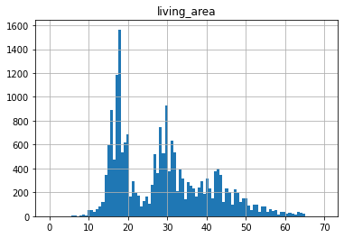

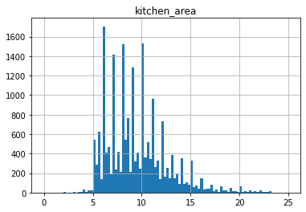

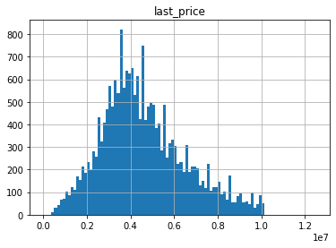

```python
data.hist('total_area', bins=100, range=(0,120));
data.hist('living_area', bins=100, range=(0,70));
data.hist('kitchen_area', bins=100, range=(0,25));
data.hist('last_price', bins=100, range=(0,1.25e+07));
```

После того, как проработали выбросы, можно приступать к анализу параметров, изучить их взаимосвязи и влияние друг на друга.

**Изучим, как быстро продавались квартиры по столбцу `days_exposition`. Для этого построим гистраграмму, посчитаем среднее и медиану, а также посмотрим какие именно параметры влияют на более быструю продажу квартир.**

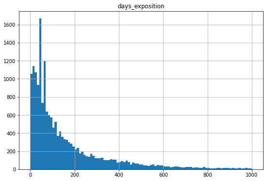

```python
data.hist('days_exposition', bins=100, range=(0,1000), grid=True, figsize=(9, 6));
```

Наиболее часто квартиры продаются в течение 100 дней с момента публикации объявления.

```python
# Посчитаем медиану по количеству дней размещения объявлений:
print('Медианное количество дней по размещению объявлений составляет:', data['days_exposition'].median())
```

```
Медианное количество дней по размещению объявлений составляет: 90.00000000000001
```

```python
# Посчитаем среднее по количеству дней размещения объявлений:
print('Среднее количество дней по размещению объявлений составляет:', data['days_exposition'].mean())
```

```
Среднее количество дней по размещению объявлений составляет: 169.0452736318408
```

Судя по гистограмме выше и ниже приведенным расчетам, можно наблюдать достаточное количество объявлений, снятых с публикации в течение первых 30 дней. Это, скорее всего, свидетельствует о выбросах, и может характеризоваться тем, что объявления об этих квартирах были размещены и на других платформах ранее и именно через ту платформу проходила сделка. Либо было приянто решение об снятии с публикации объявлений по ряду обстоятельств. Поэтому, такое количество дней размещения объявлений не рассматриваем как быструю продажу.

```python
print('Количество объявлений снятых с публикации в первый месяц:', data[data['days_exposition'] <= 30]['days_exposition'].count())
```

```
Количество объявлений снятых с публикации в первый месяц: 3459
```

**Вывод:** Исходя из выше представленного, можно предположить, что быстрые продажи это сделки, совершенные в первые 31-95 дней с момента публикации обявления, а необычно долгими те, которые размещены более 170 дней.

| days_exposition | count | sum | fraction |
| --- | --- | --- | --- |
| 847.0 | 1 | 740000.0 | 740000.0 |
| 1396.0 | 1 | 1150000.0 | 1150000.0 |
| 1021.0 | 1 | 1199000.0 | 1199000.0 |
| 786.0 | 1 | 1200000.0 | 1200000.0 |
| 1105.0 | 1 | 1200000.0 | 1200000.0 |
| ... | ... | ... | ... |
| 912.0 | 1 | 9500000.0 | 9500000.0 |
| 957.0 | 1 | 9700000.0 | 9700000.0 |
| 893.0 | 1 | 9900000.0 | 9900000.0 |
| 1434.0 | 1 | 9950000.0 | 9950000.0 |
| 1060.0 | 1 | 10000000.0 | 10000000.0 |

1061 rows × 3 columns

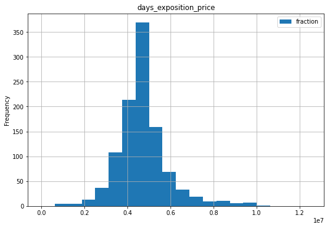

```python
days_exposition_price = data.pivot_table(index='days_exposition', values='last_price', aggfunc = {'count', 'sum'})
days_exposition_price['fraction'] = round(days_exposition_price['sum']/days_exposition_price['count'],5)
days_exposition_price = days_exposition_price.sort_values('fraction')
display(days_exposition_price)
days_exposition_price.plot( y='fraction', kind = 'hist', title = 'days_exposition_price', xlabel = 'last_price', bins = 20, range = (0,1.25e+07), grid=True, figsize=(9, 6));
```

По получившейся гистаграмме, можно обнаружить, что быстрее всего квартиры продаются конечной стоимостью в диапазоне до 5 млн.руб. и после 8 млн.руб. Это может объясняться тем, что таких объявлений, в целом, представленно меньше.

| days_exposition | total_area |
| --- | --- |
| 875.0 | 25.3000 |
| 705.0 | 28.0000 |
| 708.0 | 28.6000 |
| 905.0 | 29.0000 |
| 511.0 | 29.4675 |
| ... | ... |
| 957.0 | 98.0000 |
| 1209.0 | 98.0000 |
| 912.0 | 98.5000 |
| 893.0 | 105.2000 |
| 538.0 | 106.0000 |

1061 rows × 1 columns

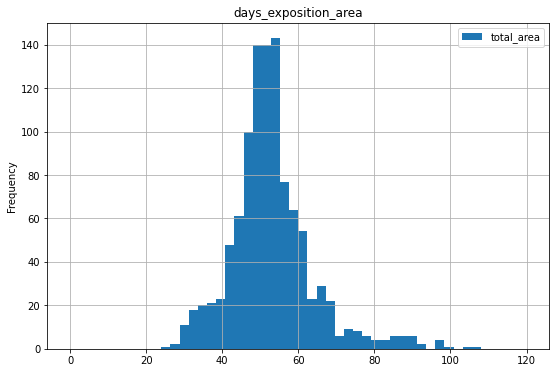

```python
days_exposition_area = data.pivot_table(index='days_exposition', values='total_area')
days_exposition_area = days_exposition_area.sort_values('total_area')
display(days_exposition_area)
days_exposition_area.plot(y='total_area', kind = 'hist', title = 'days_exposition_area', bins = 50, range = (0,120), grid=True, figsize=(9, 6));
```

По получившейся гистаграмме, можно обнаружить, что быстрее всего квартиры продаются общей площадью в диапазоне до 50 кв.м. и после 80 кв.м. Это может объясняться тем, что таких объявлений, в целом, представленно меньше.

**Далее определим, какие факторы больше всего влияют на общую (полную) стоимость объекта**

Для этого составим сводные таблицы по рассматриваемым параметрам и построим графики.

```
Корреляция между last_price и total_area составляет: 65.25%
```

| last_price | total_area |
| --- | --- |
| 430000.0 | 42.200000 |
| 440000.0 | 40.000000 |
| 450000.0 | 40.100000 |
| 470000.0 | 40.833333 |
| 480000.0 | 32.000000 |
| ... | ... |
| 9998000.0 | 65.600000 |
| 9999000.0 | 78.600000 |
| 9999870.0 | 65.000000 |
| 9999999.0 | 91.700000 |
| 10000000.0 | 77.940816 |

2009 rows × 1 columns

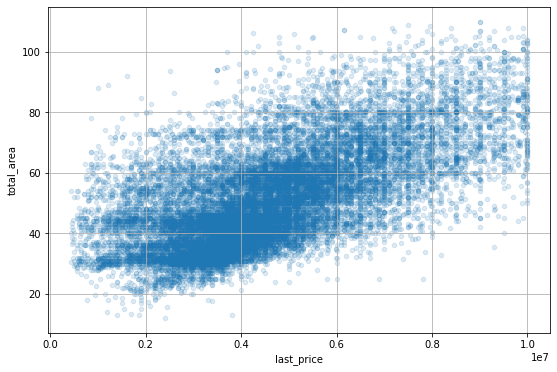

```python
# Рассмотрим влияние параметра "общая площадь" на стоимость объекта недвижимости:
corr_total_area = data['last_price'].corr(data['total_area'])
print(f'Корреляция между last_price и total_area составляет: {corr_total_area:0.2%}')
price_total_area = data.pivot_table(index='last_price', values='total_area')
display(price_total_area)
data.query('last_price < 400000000').plot(x='last_price', y='total_area', kind='scatter', alpha=0.15, grid=True, figsize=(9, 6));
```

```
Корреляция между last_price и living_area составляет: 52.98%
```

| last_price | living_area |
| --- | --- |
| 430000.0 | 21.500000 |
| 440000.0 | 18.000000 |
| 450000.0 | 22.462500 |
| 470000.0 | 25.550000 |
| 480000.0 | 16.000000 |
| ... | ... |
| 9998000.0 | 33.000000 |
| 9999000.0 | 44.000000 |
| 9999870.0 | 31.010000 |
| 9999999.0 | 51.500000 |
| 10000000.0 | 45.729796 |

2009 rows × 1 columns

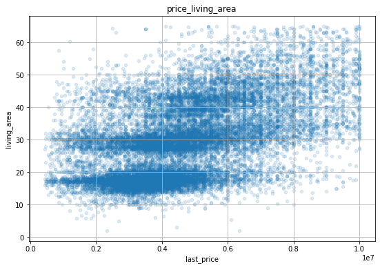

```python
# Рассмотрим влияние параметра "жилая площадь" на стоимость объекта недвижимости:
corr_living_area = data['last_price'].corr(data['living_area'])
print(f'Корреляция между last_price и living_area составляет: {corr_living_area:0.2%}')
price_living_area = data.pivot_table(index='last_price', values='living_area')
display(price_living_area)
data.query('last_price < 400000000').plot(x='last_price', y='living_area', title = 'price_living_area', kind='scatter', alpha=0.15, grid=True, figsize=(9, 6));
```

**Вывод:** по коэффициенту корреляции и графику видно, что присутствует положительная зависимость, то есть с увеличением жилой площади квартиры увеличивается и стоимость квартиры.

```
Корреляция между last_price и kitchen_area составляет: 43.26%
```

| last_price | kitchen_area |
| --- | --- |
| 430000.0 | 9.750000 |
| 440000.0 | 12.000000 |
| 450000.0 | 7.356250 |
| 470000.0 | 9.200000 |
| 480000.0 | 9.600000 |
| ... | ... |
| 9998000.0 | 9.000000 |
| 9999000.0 | 16.100000 |
| 9999870.0 | 16.250000 |
| 9999999.0 | 12.500000 |
| 10000000.0 | 11.760878 |

2009 rows × 1 columns

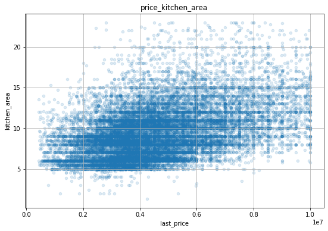

```python
# Рассмотрим влияние параметра "площадь кухни" на стоимость объекта недвижимости:
corr_kitchen_area = data['last_price'].corr(data['kitchen_area'])
print(f'Корреляция между last_price и kitchen_area составляет: {corr_kitchen_area:0.2%}')
price_kitchen_area = data.pivot_table(index='last_price', values='kitchen_area')
display(price_kitchen_area)
data.query('last_price < 400000000').plot(x='last_price', y='kitchen_area', title = 'price_kitchen_area', kind='scatter', alpha=0.15, grid=True, figsize=(9, 6));
```

**Вывод:** по коэффициенту корреляции и графику видно, что присутствует положительная зависимость, то есть с увеличением площади кухни квартиры увеличивается и стоимость квартиры. Данная связь уже меньше, чем у двух параметров, рассмотренных выше, но всё же связь положительна.

```
Корреляция между last_price и rooms составляет: 40.73%
```

| rooms | last_price |
| --- | --- |
| 0 | 2.897070e+06 |
| 1 | 3.724754e+06 |
| 2 | 4.802205e+06 |
| 3 | 5.638997e+06 |
| 4 | 5.921382e+06 |
| 5 | 6.276923e+06 |

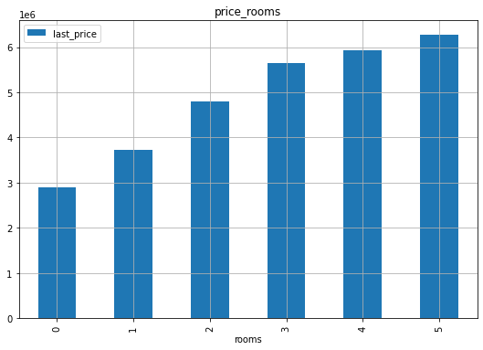

```python
# Рассмотрим влияние параметра "количество комнат" на стоимость объекта недвижимости:
corr_rooms = data['last_price'].corr(data['rooms'])
print(f'Корреляция между last_price и rooms составляет: {corr_rooms:0.2%}')
price_rooms = data.pivot_table(index='rooms', values='last_price')
display(price_rooms)
data.pivot_table(index='rooms', values='last_price').plot(y='last_price', kind='bar', title = 'price_rooms', grid=True, figsize=(9, 6));
```

**Вывод:** по коэффициенту корреляции и графику видно, что присутствует положительная зависимость, то есть с увеличением количества комнат в квартире увеличивается и стоимость квартиры.

```
Корреляция между last_price и floor составляет: 15.16%
```

| floor_type | last_price |
| --- | --- |
| другой | 4.771712e+06 |
| первый | 3.972075e+06 |
| последний | 4.166678e+06 |

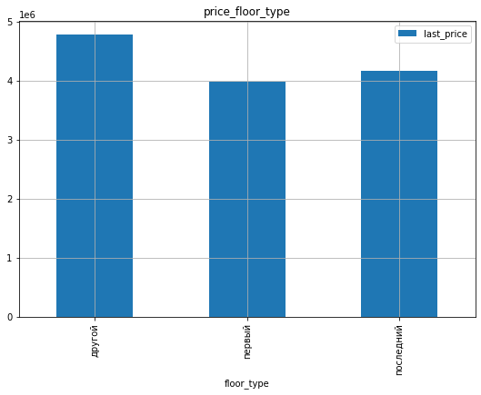

```python
# Рассмотрим влияние параметра "тип этажа" на стоимость объекта недвижимости:
corr_floor_type = data['last_price'].corr(data['floor'])
print(f'Корреляция между last_price и floor составляет: {corr_floor_type:0.2%}')
price_floor_type = data.pivot_table(index='floor_type', values='last_price')
display(price_floor_type)
data.pivot_table(index='floor_type', values='last_price').plot(y='last_price', title = 'price_floor_type', kind='bar', grid=True, figsize=(9, 6));
```

**Вывод:** коэффициент корреляции положительный, но и достаточно маленький, что свидетельствует о положительной слабой связи. По графику видно, что дороже стоят квартиры, расположенные выше первого этажа.

```
Корреляция между last_price и day_publication составляет: -1.03%
```

| day_publication | last_price |
| --- | --- |
| 0 | 4.600297e+06 |
| 1 | 4.580621e+06 |
| 2 | 4.626537e+06 |
| 3 | 4.571821e+06 |
| 4 | 4.592848e+06 |
| 5 | 4.525904e+06 |
| 6 | 4.522093e+06 |

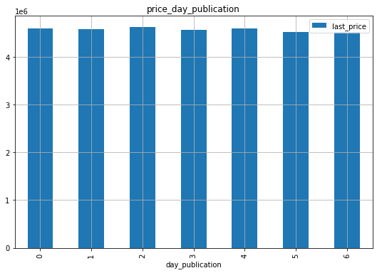

```python
# Рассмотрим влияние параметра "дня размещения" на стоимость объекта недвижимости:
corr_day_publication = data['last_price'].corr(data['day_publication'])
print(f'Корреляция между last_price и day_publication составляет: {corr_day_publication:0.2%}')
price_day_publication = data.pivot_table(index='day_publication', values='last_price')
display(price_day_publication)
data.pivot_table(index='day_publication', values='last_price').plot(y='last_price', title = 'price_day_publication', kind='bar', grid=True, figsize=(9, 6));
```

**Вывод:** стоимость квартиры практически совсем не зависит от дня публикации объявления о продаже, это подтверждает коэффициент корреляции, близкий к нулу и график.

```
Корреляция между last_price и month_publication составляет: 0.04%
```

| month_publication | last_price |
| --- | --- |
| 1 | 4.566717e+06 |
| 2 | 4.579712e+06 |
| 3 | 4.563380e+06 |
| 4 | 4.705214e+06 |
| 5 | 4.570020e+06 |
| 6 | 4.449070e+06 |
| 7 | 4.586320e+06 |
| 8 | 4.583483e+06 |
| 9 | 4.562568e+06 |
| 10 | 4.589443e+06 |
| 11 | 4.592714e+06 |
| 12 | 4.609916e+06 |

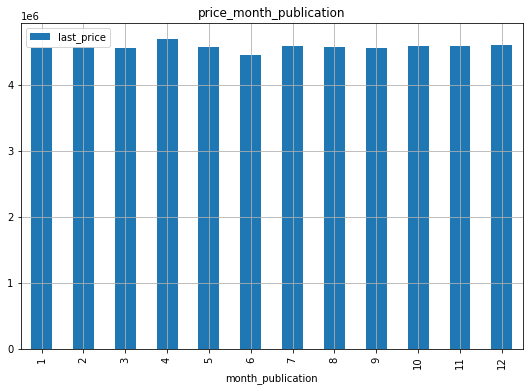

```python
# Рассмотрим влияние параметра "месяца размещения" на стоимость объекта недвижимости:
corr_month_publication = data['last_price'].corr(data['month_publication'])
print(f'Корреляция между last_price и month_publication составляет: {corr_month_publication:0.2%}')
price_month_publication = data.pivot_table(index='month_publication', values='last_price')
display(price_month_publication)
data.pivot_table(index='month_publication', values='last_price').plot(y='last_price', title = 'price_month_publication', kind='bar', grid=True, figsize=(9, 6));
```

**Вывод:** стоимость квартиры практически совсем не зависит от месяца публикации объявления о продаже, это подтверждает коэффициент корреляции, близкий к нулу и график.

```
Корреляция между last_price и year_publication составляет: 1.85%
```

| year_publication | last_price |
| --- | --- |
| 2014 | 5.142957e+06 |
| 2015 | 4.815373e+06 |
| 2016 | 4.533283e+06 |
| 2017 | 4.506074e+06 |
| 2018 | 4.535891e+06 |
| 2019 | 4.889865e+06 |

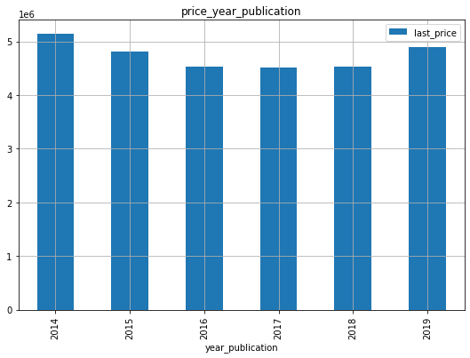

```python
# Рассмотрим влияние параметра "года размещения" на стоимость объекта недвижимости:
corr_year_publication = data['last_price'].corr(data['year_publication'])
print(f'Корреляция между last_price и year_publication составляет: {corr_year_publication:0.2%}')
price_year_publication = data.pivot_table(index='year_publication', values='last_price')
display(price_year_publication)
data.pivot_table(index='year_publication', values='last_price').plot(y='last_price', title = 'price_year_publication', kind='bar', grid=True, figsize=(9, 6));
```

**ОБЩИЙ ВЫВОД О ВЛИЯНИИ ФАКТОРОВ НА СТОИМОСТЬ КВАРТИРЫ**

Наиболее сильно влияют на стоимость квартиры следующие факторы:

- общая площадь квартиры
- жилая площадь квартиры
- площадь кухни
- количество комнат

В меньшей степени влияют (практически не влияют) следующие факторы:

- этаж, на котором расположена квартира (первый, последний, другой);
- день размещения объявления;
- месяц размещения объявления;
- год размещения объявления.

**Определим населённые пункты с наибольшим числом объявлений с самой высокой и низкой стоимостью квадратного метра**

```python
#Выведем список с количеством встречаемости каждого населенного пункта:
data['locality_name'].value_counts().head(10)
```

```
Санкт-Петербург      12797
поселок Мурино         553
поселок Шушары         431
Всеволожск             386
Колпино                332
поселок Парголово      323
Пушкин                 322
Гатчина                301
деревня Кудрово        291
Выборг                 222
Name: locality_name, dtype: int64
```

```python
populated_locality = data.pivot_table(index = 'locality_name', values = ['last_price', 'total_area'], aggfunc={'sum', 'count'})
populated_locality.columns = ['last_price_count', 'last_price_sum', 'total_area_count', 'total_area_sum']
populated_locality.sort_values('total_area_count', ascending = False, inplace=True)
populated_locality = populated_locality.iloc[:10]
populated_locality['price_meter'] = populated_locality['last_price_sum']/populated_locality['total_area_sum']
populated_locality.sort_values('price_meter', ascending = False, inplace=True)
populated_locality.pop('last_price_count')
display(populated_locality)
```

| locality_name | last_price_sum | total_area_count | total_area_sum | price_meter |
| --- | --- | --- | --- | --- |
| Санкт-Петербург | 6.836607e+10 | 12797 | 665522.89 | 102725.351056 |
| Пушкин | 1.661192e+09 | 322 | 16682.83 | 99574.950053 |
| деревня Кудрово | 1.209325e+09 | 291 | 13279.96 | 91063.869921 |
| поселок Парголово | 1.439978e+09 | 323 | 16357.61 | 88031.103505 |
| поселок Мурино | 2.012163e+09 | 553 | 24229.94 | 83044.486697 |
| поселок Шушары | 1.736286e+09 | 431 | 22710.16 | 76454.150873 |
| Колпино | 1.265279e+09 | 332 | 17121.74 | 73898.987252 |
| Гатчина | 1.023240e+09 | 301 | 14984.68 | 68285.766530 |
| Всеволожск | 1.397348e+09 | 386 | 21201.52 | 65907.924809 |
| Выборг | 6.665750e+08 | 222 | 11526.56 | 57829.482517 |

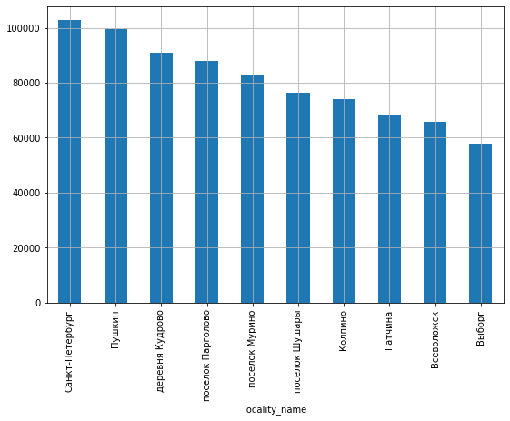

```python
populated_locality['price_meter'].plot(kind='bar', grid=True, figsize=(9, 6));
```

**Вывод:** Наиболее популярным местоположением с самой высокой стоимостью квадратного метра является Санкт-Петербург с количеством объявлений 12797 шт. и средней стоимостью одного квадратного метра примерно 102725.4 рублей. Местоположение из десятки наиболее популярных населенных пунктов по количеству объявлений с самой низкой стоимостью квадратного метра является Выборг. Выборг обладает 222 объявлениями о продаже квартир со средней стоимостью одгого квадратного метра примерно 57829.5 рублей.

**Определим, как стоимость объектов зависит от расстояния до центра города**

```python
data[data['locality_name'] == 'Санкт-Петербург']
```

|  | total_images | last_price | total_area | first_day_exposition | rooms | ceiling_height | floors_total | living_area | floor | is_apartment | ... | ponds_around3000 | ponds_nearest | days_exposition | remoteness_category | price_meter | day_publication | month_publication | year_publication | floor_type | cityCenters_nearest_km |
| --- | --- | --- | --- | --- | --- | --- | --- | --- | --- | --- | --- | --- | --- | --- | --- | --- | --- | --- | --- | --- | --- |
| 2 | 10 | 5196000.0 | 56.0 | 2015-08-20 | 2 | 2.60 | 5 | 34.3 | 4 | False | ... | 2 | 574.0 | 558.0 | C | 92785.714286 | 3 | 8 | 2015 | другой | 13 |
| 7 | 5 | 7915000.0 | 71.6 | 2019-04-18 | 2 | 2.60 | 24 | 35.8 | 22 | False | ... | 0 | NaN | NaN | C | 110544.692737 | 3 | 4 | 2019 | другой | 11 |
| 9 | 18 | 5400000.0 | 61.0 | 2017-02-26 | 3 | 2.50 | 9 | 43.6 | 7 | False | ... | 0 | NaN | 289.0 | C | 88524.590164 | 6 | 2 | 2017 | другой | 15 |
| 10 | 5 | 5050000.0 | 39.6 | 2017-11-16 | 1 | 2.67 | 12 | 20.3 | 3 | False | ... | 2 | 553.0 | 137.0 | C | 127525.252525 | 3 | 11 | 2017 | другой | 13 |
| 15 | 16 | 4650000.0 | 39.0 | 2017-11-18 | 1 | 2.60 | 14 | 20.5 | 5 | False | ... | 1 | 296.0 | 19.0 | C | 119230.769231 | 5 | 11 | 2017 | другой | 14 |
| ... | ... | ... | ... | ... | ... | ... | ... | ... | ... | ... | ... | ... | ... | ... | ... | ... | ... | ... | ... | ... | ... |
| 23687 | 6 | 3200000.0 | 39.0 | 2017-12-16 | 1 | 2.60 | 9 | 20.0 | 6 | False | ... | 0 | NaN | 38.0 | C | 82051.282051 | 5 | 12 | 2017 | другой | 16 |
| 23688 | 19 | 9200000.0 | 101.0 | 2019-04-01 | 3 | 3.05 | 15 | 63.0 | 12 | False | ... | 0 | NaN | 23.0 | C | 91089.108911 | 0 | 4 | 2019 | другой | 14 |
| 23689 | 13 | 3550000.0 | 35.3 | 2018-02-28 | 1 | 2.86 | 15 | 16.3 | 4 | False | ... | 2 | 652.0 | 29.0 | C | 100566.572238 | 2 | 2 | 2018 | другой | 16 |
| 23690 | 3 | 5500000.0 | 52.0 | 2018-07-19 | 2 | 2.80 | 5 | 31.0 | 2 | False | ... | 0 | NaN | 15.0 | B | 105769.230769 | 3 | 7 | 2018 | другой | 6 |
| 23691 | 11 | 9470000.0 | 72.9 | 2016-10-13 | 2 | 2.75 | 25 | 40.3 | 7 | False | ... | 1 | 806.0 | 519.0 | A | 129903.978052 | 3 | 10 | 2016 | другой | 4 |

12797 rows × 29 columns

| cityCenters_nearest_km | price_km_spb_mean |
| --- | --- |
| 0 | 6.719418e+06 |
| 1 | 7.224128e+06 |
| 2 | 6.995937e+06 |
| 3 | 6.626410e+06 |
| 4 | 6.973968e+06 |
| 5 | 6.860102e+06 |
| 6 | 6.302940e+06 |
| 7 | 6.161071e+06 |
| 8 | 5.736275e+06 |
| 9 | 5.119841e+06 |
| 10 | 5.114488e+06 |
| 11 | 5.139680e+06 |
| 12 | 5.120004e+06 |
| 13 | 5.319996e+06 |
| 14 | 5.134943e+06 |
| 15 | 5.018610e+06 |
| 16 | 4.895809e+06 |
| 17 | 4.565657e+06 |
| 18 | 4.665942e+06 |
| 19 | 4.568362e+06 |
| 20 | 5.958302e+06 |
| 21 | 4.951780e+06 |
| 22 | 4.999883e+06 |
| 23 | 4.126867e+06 |
| 24 | 3.862235e+06 |
| 25 | 3.985385e+06 |
| 26 | 3.575000e+06 |
| 27 | 2.250000e+06 |
| 28 | 4.611667e+06 |
| 29 | 3.833333e+06 |

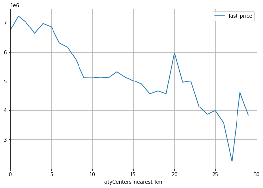

```python
price_km_spb = data.query('locality_name == "Санкт-Петербург"').pivot_table(index='cityCenters_nearest_km', values='last_price', aggfunc='mean')
price_km_spb.columns = ['price_km_spb_mean']
price_km_spb.sort_values('cityCenters_nearest_km', ascending = True, inplace=True)
display(price_km_spb)
data.query('locality_name == "Санкт-Петербург"').pivot_table(index='cityCenters_nearest_km', values='last_price').plot(grid=True, style='-', xlim=(0,30), figsize=(9, 6))
plt.show()
```

### Общий вывод

По итогу проекта, был проведен исследовательский анализ данных, благодаря которому были установлены параметры, влияющие на цену объектов.

**Срок продажи квартир:**

- Наиболее часто квартиры продаются в течение 100 дней с момента публикации объявления.
- Быстрые продажи это сделки, совершенные в первые 31-95 дней с момента публикации обявления, а необычно долгими те, которые размещены более 170 дней.

**Влияние параметров на стоимость квартир:**

- Наиболее сильно влияют на стоимость квартиры следующие факторы:
  - общая площадь квартиры
  - жилая площадь квартиры
  - площадь кухни
  - количество комнат
- В меньшей степени влияют (практически не влияют) следующие факторы:
  - этаж, на котором расположена квартира (первый, последний, другой);
  - день размещения объявления;
  - месяц размещения объявления;
  - год размещения объявления.

**Влияние количества объявлений в популярных населенных пунктов на среднюю цену квадратного метра квартиры**

- Наиболее популярным местоположением с самой высокой стоимостью квадратного метра является Санкт-Петербург с количеством объявлений 12797 шт. и средней стоимостью одного квадратного метра примерно 102725.4 рублей.
- Местоположение из десятки наиболее популярных населенных пунктов по количеству объявлений с самой низкой стоимостью квадратного метра является Выборг. Выборг обладает 222 объявлениями о продаже квартир со средней стоимостью одгого квадратного метра примерно 57829.5 рублей.